# Assignment 2

Krishna Kalyan

### Question 1

The File CHBChr3-2000.rda contains genotype information (2000 SNPs) of individuals from a Chinese population of unrelated individuals. Load this data into the R environment. The file contains three data objects, X (genotype information), Allels (the possible alleles for each marker) and Pos(the position of each marker in base pairs)

```
## [1] "Alleles" "X"
```

## Question 2

Remove all SNPs that consist of missing values only from the database. Also remove all monomorphic SNPs from the data bases. Apply a chi-square test without continuity correction for Hardy-Weinberg equilibrium to each SNP. How many SNPs remain? How many SNPs are significant (use alpha = 0.05)?

```r
X = t(X)
missing_col = which(colMeans(is.na(X)) == 1)
remove_mono = which(apply(X,2,function(x) length(unique(na.omit(unlist(x))))) == 1)
remove_cols =  c(missing_col,remove_mono)
Alleles = t(Alleles)
Alleles = Alleles[-remove_cols]
X = X[,-remove_cols]
paste("snps remaining", length(Alleles))
```

```
## [1] "snps remaining 987"
```

```r
hw_pval <- function(x){
  snpg <- genotype(x,sep="")
  hw <- HWE.chisq(snpg)$p.value
  return(hw)
}
hw <- apply(X,2,hw_pval)

paste("significant snps",sum(hw > 0.05))
```

[output not shown]

## Question 3

Do you think the monomorphic markers are in Hardy-Weinberg equilibrium? Argue your answer? Since monomorphic markers have a Chi Square value of 1, they are significant. However monomorphic SNPs are uninformative in genetic association studies as there is no genotypic difference.

## Question 4

How many markers of the remaining non-monomorphic markers would you expect to be out of equilibrium by the effect of chance alone?

```
## [1] "absolute effect 46"
```

```
## [1] "effect of random chance 49.35"
```

We would expect around 5% of the non-monomorphic markers to be significant, which is around 50 markers in this case.

## Question 5

Apply an Exact test for Hardy-Weinberg equilibrium to each SNP. Use the pvaluetype=“selome” option. How many SNPs are significant (use alpha = 0.05). Is the result consistent with the chi-square test?

```r
snpg <- genotype(X,sep="")
geno_count = MakeCounts(X,Alleles)
chisel = apply(unlist(geno_count[,1:3]), 1, function(x){
  HWExact(x,pvaluetype="selome",verbose=F)$pval
  })
sig_snp = sum(chisel>0.5)
paste("significant snps HW",sig_snp)
```

```
## [1] "significant snps HW 637"
```

## Question 6

Apply a likelihood ratio test for Hardy-Weinberg equilibrium to each SNP. How many SNPs are significant (use alpha = 0.05). Is the result consistent with the chi-square test?

```r
ml <- apply(unlist(geno_count[,1:3]),1,function(x){
  HWLratio(x, verbose = F, x.linked = FALSE)$pval
  })
signif_ml <- sum(ml > 0.05)
paste("significant snps ML", signif_ml)
```

```
## [1] "significant snps ML 933"
```

## Question 7

Apply a permutation test for Hardy-Weinberg equilibrium to each SNP, using the classical chisquare test (without continuity correction) as a test statistic. Reduce the number of permutations in order to keep computation time within reasonable limits (argument nperm). How many SNPs are significant (use alfa = 0.05). Are the result consistent with the chi-square or exact test?.

```r
pvalperm <- apply(unlist(geno_count[,1:3]),1,function(x){
  HWPerm(x, nperm = 50, verbose = F)$pval
})
perm <- sum(pvalperm > 0.05)
paste("significant snps for using 50 permutations", perm)
```

```
## [1] "significant snps for using 50 permutations 951"
```

The results obtained are higer than that obtained by Chi-Square/ Exact Test.

## Question 8

Depict all SNPs simultaeneously in a ternary plot, and comment on your result (because many genotype counts repeat, you may use UniqueGenotypeCounts to speed up the computations)

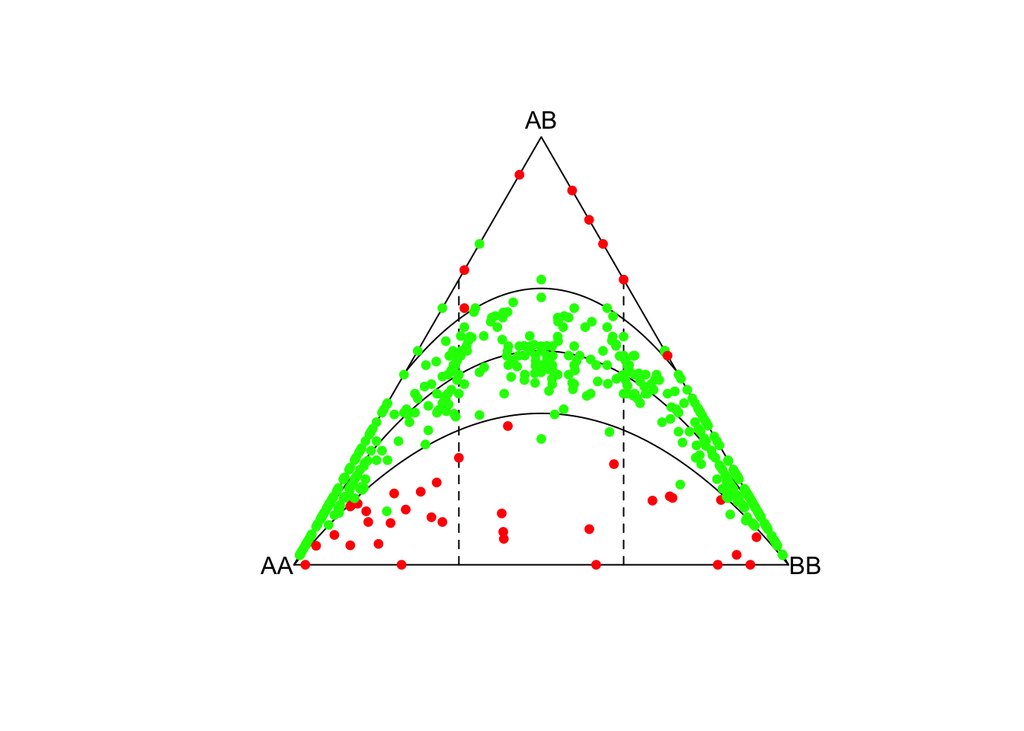

```r
ug <- UniqueGenotypeCounts(unlist(geno_count[,1:3]),verbose=F)
ternary <- HWTernaryPlot(ug[,c(1:3)])
```

```r
ternary$percinrange
```

```
## [1] 29.14
```

## Question 9

Make a histogram of the p-values obtained in the chi-square test. What distribution would you expect if HWE would hold for the data set? What distribution do you observe? Also make a Q-Q plot of the p-values obtained in the chi-square test against the quantiles of the distribution that you consider relevant. What is your conclusion?

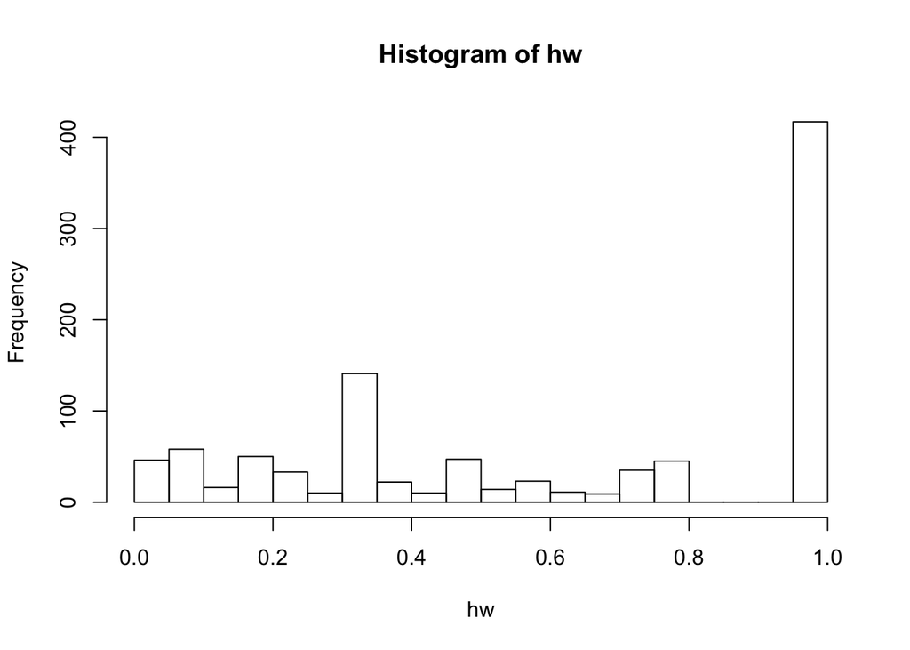

```r
hist(hw,breaks = 20)
```

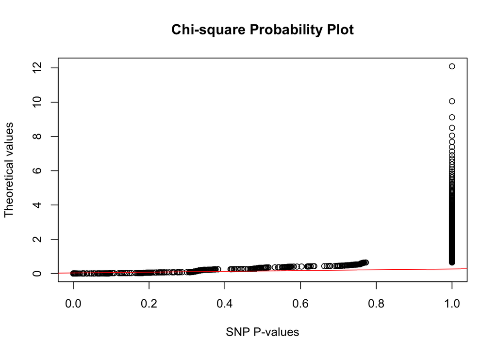

```r
chi.sq <- qchisq(ppoints(ncol(X)), df = 1)
qqplot(hw,chi.sq, main="Chi-square Probability Plot",
       xlab= "SNP P-values", ylab="Theoretical values")
qqline(hw, distribution = function(p) qchisq(p,df = 3),col="red")
```

## Question 10

Imagine that for a particular marker the counts of the two homozygotes are accidentally interchanged. Would this affect the statistical tests for HWE? Argue your answer.

```r
gene1 <- c(AA=10, AB=20, BB=30)
gene2 <- c(AA=30, AB=20, BB=10)
HWChisq(gene1,verbose = F)$pval == HWChisq(gene2,verbose = F)$pval
```

```
## [1] TRUE
```

According to the Chi-Square test conducted above and comparing the p-values we see that the statistical test will not change if the homozygotes are interchanged.

## Question 11

Compute the inbreeding coefficient ($\hat{f}$) for each SNP, and make a histogram of $\hat{f}$. You can use function HWf for this purpose. Give descriptive statistics (mean, standard deviation, etc) of $\hat{f}$ calculated over the set of SNPs. What distribution do you think $\hat{f}$ follows? Use a probability plot to confirm your idea.

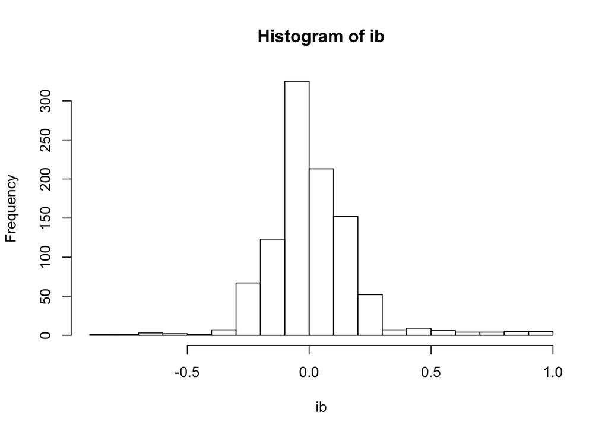

```r
ib <- apply(unlist(geno_count[,1:3]),1,function(x) HWf(x))
hist(ib, breaks=20)
```

```r
M = summary(ib)
paste(c("mean ","standard deviation ", "median ", "minimum ", "maximum"),
      c(M[4], round(sd(ib),2), M[3],M[1],M[6])  )
```

```
## [1] "mean  0.01612"            "standard deviation  0.19"
## [3] "median  -0.01124"         "minimum  -0.8378"
## [5] "maximum 1"
```

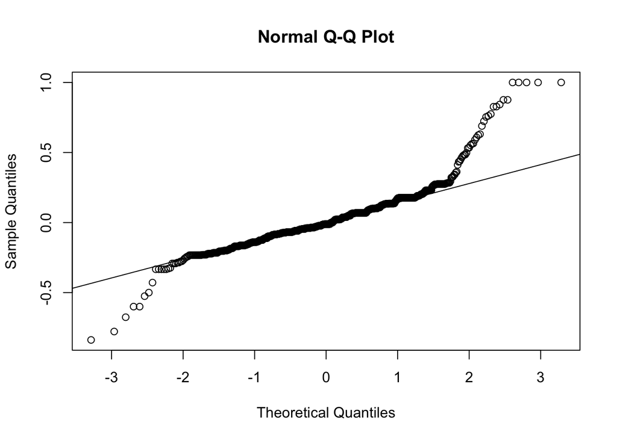

```r
qqnorm(ib)
qqline(ib)
```

The QQplot distribution looks normal, since majority of the observations are on the diagonal line. A coefficient of inbreeding can be calculated for an individual, as a measure for the amount of pedigree collapse within that individual’s genealogy.In general, the higher the level of inbreeding the closer the coefficient of relationship approaches a value of 1, expressed as a percentage,and approaches a value of 0 for individuals with arbitrarily remote common ancestors. In the histogram we observe that the inbreeding coefficient seems to be centered around 0.

## Question 12

Make a plot of the observed chi-square statistics against the inbreeding coefficient ($\hat{f}$). What do you observe? Can you give an equation that relates the two statistics?

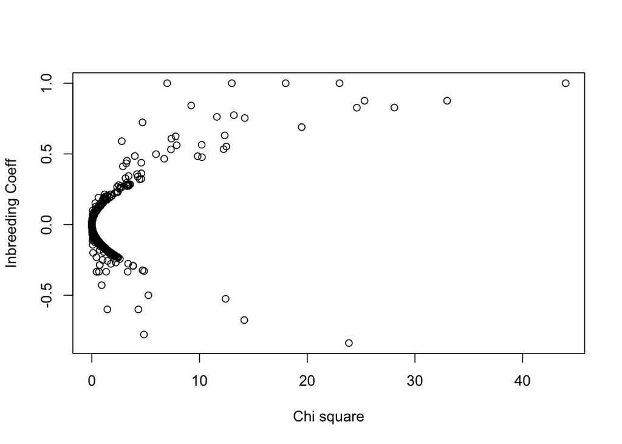

```r
chi_sq <- apply(unlist(geno_count[,1:3]),1,function(x){
  HWChisq(x,cc = 0,verbose=F)$chi
  })

plot(x=chi_sq,y=ib, xlab= "Chi square", ylab="Inbreeding Coeff")
```

We observe an eliptical trend for the above plot. It seems a squared function for $y$. This being similar to $x=y^2$. We also observe that number of observations decrease as Chi-Squre increases.

## Question 13

Make a chi-square probability plot of the observed chi-square statistics against their theoretical quantiles. Does the sample statistic follow a chi-square distribution?

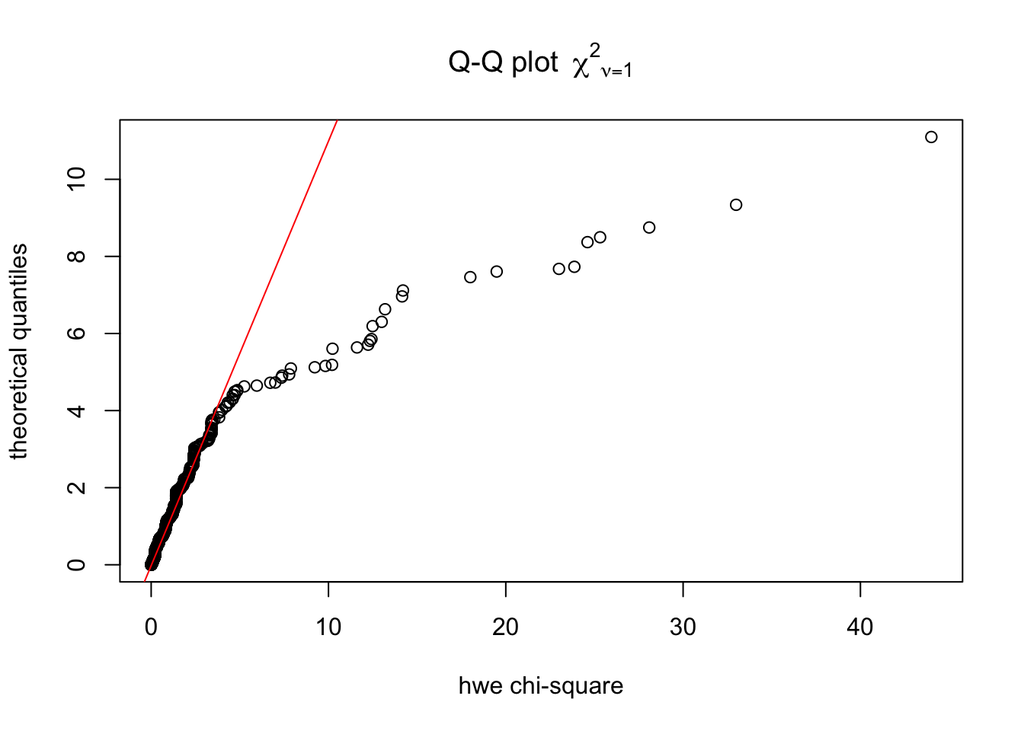

```r
y <- rchisq(length(chi_sq), df = 1)

qqplot(chi_sq, y,main = expression("Q-Q plot" ~~ {chi^2}[nu == 1]),
       ylab = "theoretical quantiles",xlab = "hwe chi-square")
qqline(y, distribution = function(p) qchisq(p, df = 1),col=2)
```

It appears that most of the data of the SNPs, do follow a chi-square distribution, since by plotting the chi square values of the HWE (without continuity) against the computed theoretical quantiles for chi-square, it appears to follow a linear trend. Some other values seem to differ, but they are not the mayority. In any case, a proof of hypothesis would have to be computed before being certain of this conclusion.

## Question 14

Simulate SNPs under the assumption of Hardy-Weinberg equilibrium. Simulate the SNPs of this database, and take care to match each of the SNPs in your database with a simulated SNP that has the same sample size and allele frequency. You can use function HWData of the HardyWeinberg package for this purpose. Compare the distribution of the observed chi-square statistics with the distribution of the chi-square statistics of the simulated SNPs by making a Q-Q plot. What do you observe? State your conclusions.

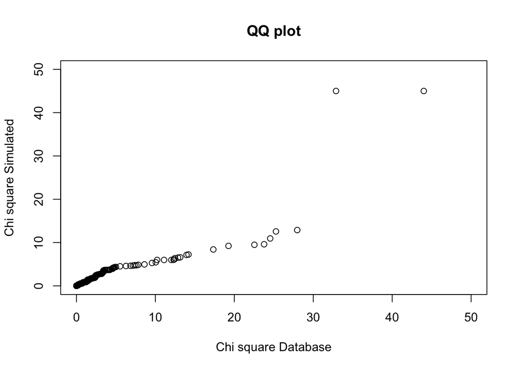

```r
geno <- unlist(geno_count[,1:3])
n = unname(rowSums(unlist(geno_count[,1:3])))
p = unname(apply(geno,1,maf))
simul <-c()
for(i in 1:length(n)){
  s <- HWData(1,n=n[i],p=p[i])
  simul <- rbind(simul,s)
}
chisq_simul <- apply(t(simul),2,function(x){
  HWChisq(x,cc = 0,verbose=F)$chi
  })

qqplot(x=chi_sq,y=chisq_simul,xlab = "Chi square Database",
       ylab="Chi square Simulated", main="QQ plot",
       xlim=c(0,50),ylim=c(0,50))
```

## Question 15

Do you think genotyping error is a problem for the database you just studied? Explain your opinion.

Genotyping errors are present in almost all genetic data and can affect biological conclusions of a study, particularly for studies based on individual identification and parentage. We can use statistical approach to estimate these error. I used the internet where they mentioned that

- repeat genotyping 5% of samples
- comparing unintentionally recaptured individuals
- Mendelian inheritance error checking

However in our dataset we might have genotyping error. We ould estimate it by using a statistical appoach.